# Single-Cell RNA-seq Analysis in R — Full Pipeline

## 3.6 SingleR · 自動註解並比對

```r
ref  <- MouseRNAseqData()                              # 小鼠參考資料庫 mouse reference
pred <- SingleR(test = GetAssayData(sc_integrated, layer = "data"),
                ref = ref, labels = ref$label.main,
                clusters = sc_integrated$seurat_clusters)   # 逐群標記 label per cluster
sc_integrated$SingleR <- pred$labels[match(sc_integrated$seurat_clusters,
                                           rownames(pred))]
table(manual = sc_integrated$celltype, SingleR = sc_integrated$SingleR)  # 手動 vs 自動
```

```
##               SingleR
## manual         Cardiomyocytes Endothelial cells Fibroblasts Hepatocytes
##   Keratinocyte              0                 0       19157           0
##   Fibroblast                0                 0        7922           0
##   Macrophage                0                 0           0           0
##   T cell                    0               874           0           0
##   Endothelial               0                 0           0           0
##   Dendritic                 0                 0           0         632
##   Cycling                   0                 0         602           0
##   Pericyte                  0                 0         458           0
##   Muscle                  138                 0           0           0
##               SingleR
## manual         Macrophages T cells
##   Keratinocyte           0    1016
##   Fibroblast             0       0
##   Macrophage          1356       0
##   T cell                 0       0
##   Endothelial          695       0
##   Dendritic              0       0
##   Cycling                0       0
##   Pericyte               0       0
##   Muscle                 0       0
```

## 3.7 Functional enrichment (ORA, Enrichr) · 功能富集

```r
# 需要連網 needs internet. 設 eval=TRUE 再跑 · set eval=TRUE to run
setEnrichrSite("Enrichr")
dbs <- c("GO_Biological_Process_2023", "KEGG_2019_Mouse", "MSigDB_Hallmark_2020")

# 例：某群的 marker 基因做富集 · enrich one cluster's markers
genes <- markers |> dplyr::filter(cluster == "8", avg_log2FC > 0.5) |> dplyr::pull(gene)
res <- enrichr(genes, dbs)
head(res[["MSigDB_Hallmark_2020"]][, c("Term","Overlap","Adjusted.P.value")], 8)
```

## 3.8 Save the annotated atlas · 存檔

```r
saveRDS(sc_integrated, "rds/skin_integrated_annotated.rds")   # 下游用 for downstream
```

# 4 Session 4 — Aging biology · 老化生物學

```r
sc <- sc_integrated                                    # 短名 shorter handle
sc$agegrp <- dplyr::recode(sc$age,                     # 8wk→young, 52wk→aged, 26wk→mid
                           "8wk" = "young", "52wk" = "aged", "26wk" = "mid")
```

## 4.1 Cell-type proportion shift · 細胞比例變化

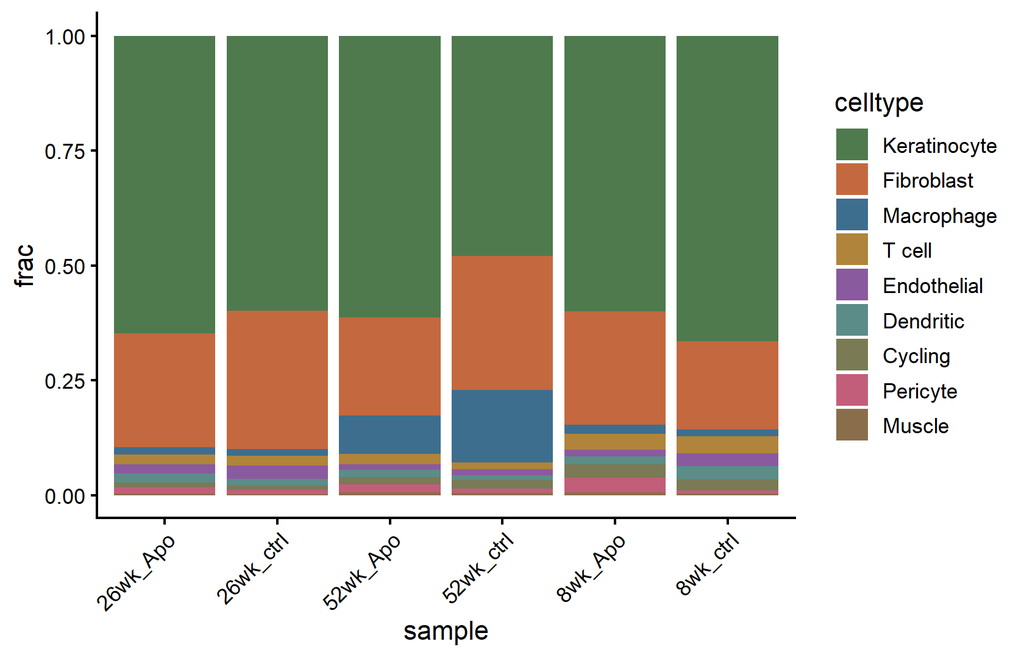

```r
prop <- sc@meta.data |>
  dplyr::count(sample, agegrp, celltype) |>
  dplyr::group_by(sample) |>
  dplyr::mutate(frac = n / sum(n))

ggplot(prop, aes(sample, frac, fill = celltype)) +     # 每樣本堆疊組成 stacked composition
  geom_col() +
  scale_fill_manual(values = ct_cols) +
  theme_classic(base_size = 13) +
  theme(axis.text.x = element_text(angle = 45, hjust = 1))
```

## 4.2 Differential expression: aged vs young · 差異表現

Compare aged vs young **within one cell type**. True *pseudobulk* (DESeq2) needs **≥3 biological replicates per group**; this dataset has only 2 samples per age (ctrl + Apo), so here we use the single-cell Wilcoxon test. When you have ≥3 replicates per group, switch to the pseudobulk block shown after. 在單一細胞型內比較。真正的 pseudobulk（DESeq2）每組需 **≥3 個生物重複**；本資料每個年齡只有 2 個樣本，故此處用單細胞 Wilcoxon 檢定；有 ≥3 重複時再換成後面的 pseudobulk 寫法。

```r
fib_cells <- subset(sc, celltype == "Fibroblast" & agegrp %in% c("young","aged"))  # 只取纖維母細胞
Idents(fib_cells) <- "agegrp"
de <- FindMarkers(fib_cells, ident.1 = "aged", ident.2 = "young")   # 單細胞 Wilcoxon；+值=老化上調
head(de, 10)
```

|  | p_val | avg_log2FC | pct.1 | pct.2 | p_val_adj |
| --- | --- | --- | --- | --- | --- |
| Fabp5 | 1.375805e-197 | -1.2082364 | 0.662 | 0.920 | 2.591466e-193 |
| Krt14 | 1.572078e-161 | -1.2216652 | 0.591 | 0.861 | 2.961167e-157 |
| Krt5 | 3.342667e-121 | -1.2257498 | 0.458 | 0.723 | 6.296248e-117 |
| Lgals7 | 1.057030e-102 | -0.8216345 | 0.759 | 0.927 | 1.991021e-98 |
| Cstdc5 | 1.866010e-95 | -1.0724130 | 0.568 | 0.774 | 3.514816e-91 |
| Aqp3 | 1.888868e-88 | -1.4691838 | 0.352 | 0.591 | 3.557872e-84 |
| Col17a1 | 9.063559e-84 | -1.5801578 | 0.229 | 0.475 | 1.707212e-79 |
| Fgfr1 | 1.653254e-78 | 1.6163517 | 0.383 | 0.151 | 3.114070e-74 |
| Col5a2 | 2.002611e-74 | 2.1010793 | 0.246 | 0.063 | 3.772118e-70 |
| Cebpg | 1.909880e-70 | 0.9113143 | 0.459 | 0.199 | 3.597451e-66 |

```r
# 有 ≥3 重複時的正確做法（此資料重複數不足，設 eval=FALSE）
# proper pseudobulk when you have >=3 replicates per group (disabled here)
pb <- AggregateExpression(sc, group.by = c("celltype","sample","agegrp"),
                          assays = "RNA", return.seurat = TRUE)
fib <- subset(pb, celltype == "Fibroblast" & agegrp %in% c("young","aged"))
Idents(fib) <- "agegrp"
de <- FindMarkers(fib, ident.1 = "aged", ident.2 = "young", test.use = "DESeq2")
```

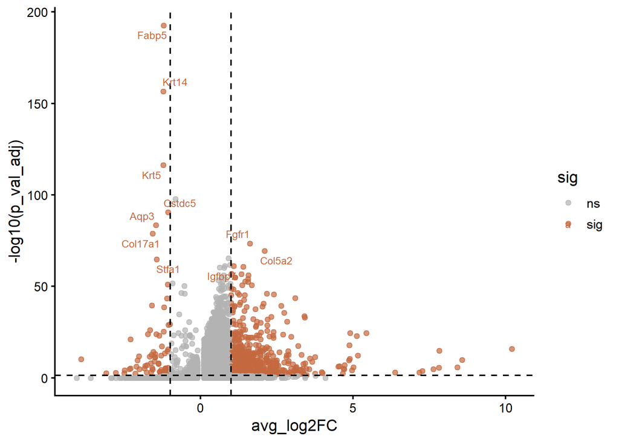

```r
# 火山圖 volcano plot
de$gene <- rownames(de)
de$sig  <- ifelse(de$p_val_adj < 0.05 & abs(de$avg_log2FC) > 1, "sig", "ns")
library(ggrepel)
ggplot(de, aes(avg_log2FC, -log10(p_val_adj), colour = sig)) +
  geom_point(alpha = .7) +
  scale_colour_manual(values = c(ns = "grey70", sig = "#C4683F")) +
  geom_vline(xintercept = c(-1, 1), linetype = "dashed") +
  geom_hline(yintercept = -log10(0.05), linetype = "dashed") +
  ggrepel::geom_text_repel(
    data = subset(de, sig == "sig") |> head(10),
    aes(label = gene), size = 3, max.overlaps = 20) +
  theme_classic(base_size = 13)
```

# 5 Session 5 — Visualization cookbook · 視覺化

All the go-to figures from the annotated object. 從註解好的物件畫出常用圖。

## 5.1 DimPlot & FeaturePlot

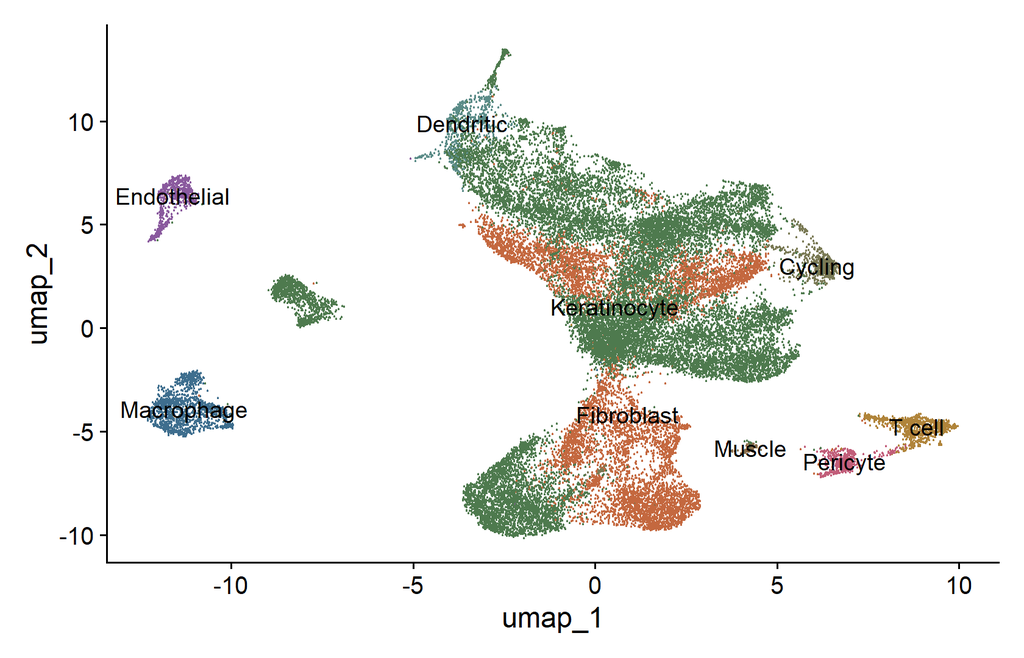

```r
DimPlot(sc, cols = ct_cols, label = TRUE) + NoLegend()
```

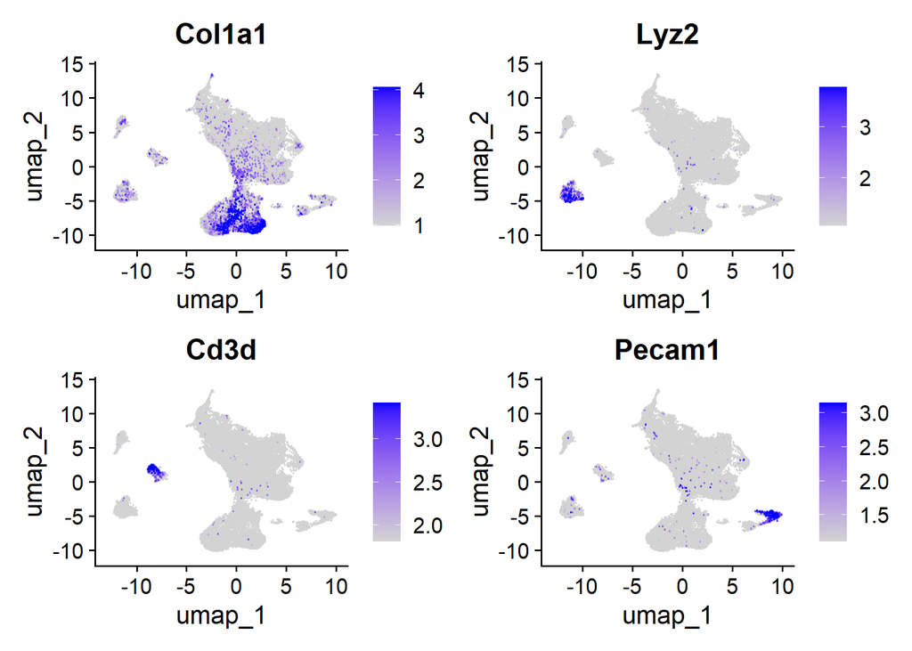

```r
FeaturePlot(sc, features = c("Col1a1","Lyz2","Cd3d","Pecam1"),
            order = TRUE, min.cutoff = "q10", max.cutoff = "q90")
```

## 5.2 VlnPlot, DotPlot, RidgePlot

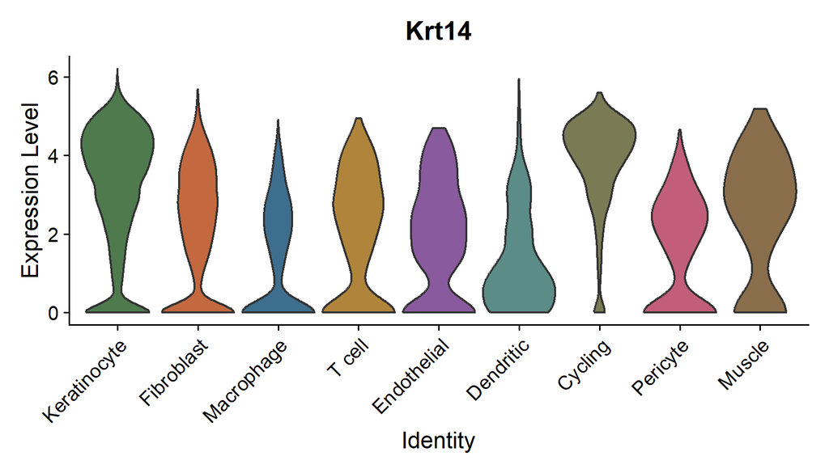

```r
VlnPlot(sc, features = "Krt14", group.by = "celltype",
        cols = ct_cols, pt.size = 0) + NoLegend()
```

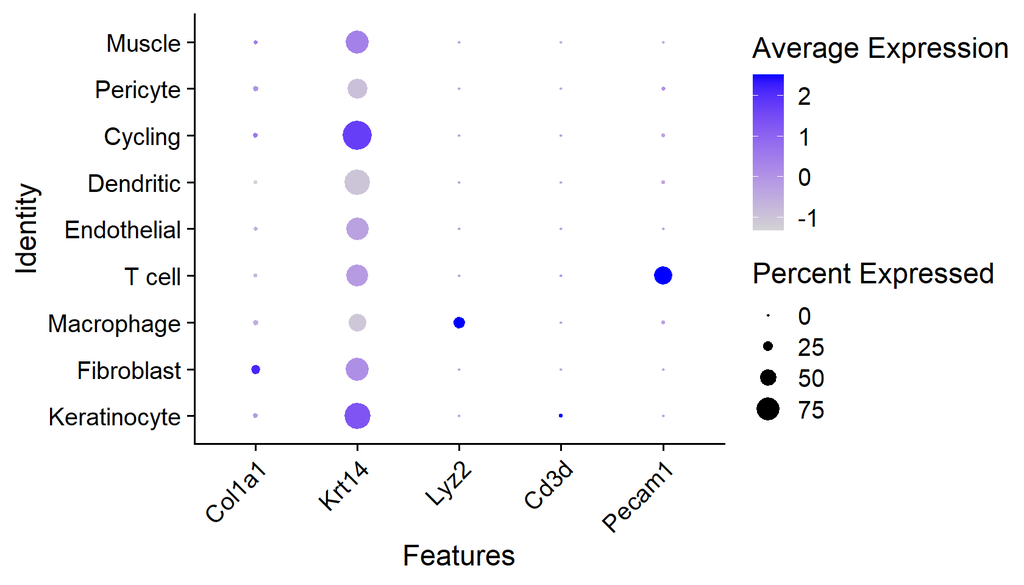

```r
DotPlot(sc, features = c("Col1a1","Krt14","Lyz2","Cd3d","Pecam1")) + RotatedAxis()
```

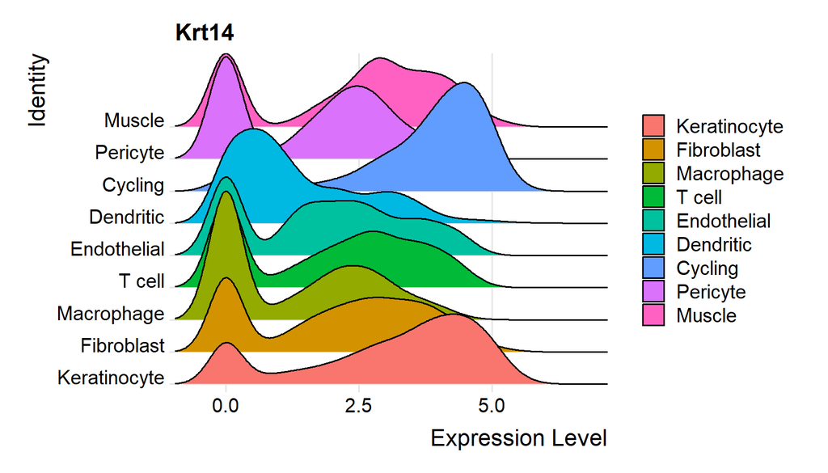

```r
RidgePlot(sc, features = "Krt14")
```

## 5.3 Multi-panel with patchwork · 拼圖

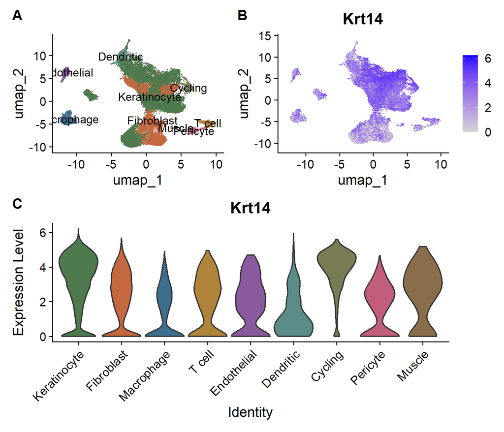

```r
p1 <- DimPlot(sc, cols = ct_cols, label = TRUE) + NoLegend()
p2 <- FeaturePlot(sc, "Krt14")
p3 <- VlnPlot(sc, "Krt14", cols = ct_cols, pt.size = 0) + NoLegend()
(p1 | p2) / p3 + plot_annotation(tag_levels = "A")
```

## 5.4 Export a figure · 存出投稿圖

```r
# 向量檔給論文、PNG 給投影片 · vector for paper, PNG for slides
ggsave("umap_celltype.pdf", p1, width = 6, height = 5)
ggsave("umap_celltype.png", p1, width = 6, height = 5, dpi = 300)
```